# KICKSTARTER PROJECT

데이터공학 프로젝트

TEAM 11:0

12/13/2019

### TEAM 11대0 (박지원, 윤정하, 정희영, 주용우)

# Project Tellus

### TEAM 11대0

데이터공학 프로젝트

#### [[ 목차 ]]

Kickstarter는 투자자와 아이디어를 가진 창업자 또는 스타트업을 연결하는 소셜 펀딩 플랫폼이다. 인터넷을 통해 한 명 또는 소수의 투자자가 아닌, 수많은 사람으로부터 동시에 투자를 받을 수 있으며 투자에 성공한 아이디어 소유자는 투자한 사람들에게 약속된 보상을 제공하게 된다. Kickstarter는 이러한 소셜 펀딩 플랫폼 사이에서 가장 유명하다.

- Kickstarter와 크라우드 펀딩
- 주제 소개와 의의 설명
- 데이터 소개
- Preprocessing
- EDA
- Modeling과 Insight
- Web 구현
- 향후 프로젝트 진행 방향
- Reference

#### [[ 역할 분담 ]]

| 팀원 | 중간고사 이전 | 중간고사 이후 |
| --- | --- | --- |
| 박지원 | Preprocessing | Modeling과 Front-end |
| 윤정하 | 자료 조사 | Modeling |
| 정희영 | Modeling | Front-end와 Server |
| 주용우 | 웹사이트 개발을 위한 서버 작업 | Modeling과 Back-end |

### Kickstarter와 크라우드 펀딩

#### >> Kickstarter?

[figure not shown]

logo

Kickstarter는 투자자와 아이디어를 가진 창업자 또는 스타트업을 연결하는 소셜 펀딩 플랫폼이다. 인터넷을 통해 한 명 또는 소수의 투자자가 아닌, 수많은 사람으로부터 동시에 투자를 받을 수 있으며 투자에 성공한 아이디어 소유자는 투자한 사람들에게 약속된 보상을 제공하게 된다. Kickstarter는 이러한 소셜 펀딩 플랫폼 사이에서 가장 유명하다. 아래 보이는 사진을 보면 미국 비즈니스 잡지 Inc.com이 발표한 2018년 크라우드펀딩 top10 회사의 1등에 kickstarter가 자리하고 있음을 알 수 있다. 소셜 펀딩은 곧 크라우드 펀딩으로도 불린다.

[figure not shown]

top10

#### >> 크라우드 펀딩의 전망

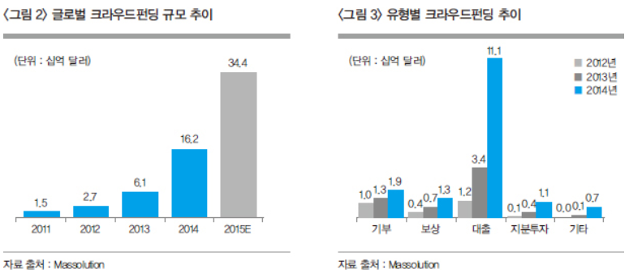

pro

크라우드펀딩 시장의 빠른 성장세는 앞으로도 지속될 것으로 전망된다. 세계은행(WB)은 글로벌 크라우드펀딩 산업 규모가 오는 2020년 900억 달러(약 100조 원)에 이를 것으로 추산했다. 2016년 발간된 ‘유엔미래보고서 2050’에서도 크라우드펀딩 시장이 주식시장을 대체할 것이라고 전망했다.

이러한 크라우드 펀딩의 폭발적 성장은 ‘’인터넷’‘과’‘소셜 미디어’’의 발달과 함께 이루어졌다고 할 수 있다. 인터넷과 소셜 미디어가 이젠 우리의 삶에서 빠질 수 없는 부분으로 자리 잡은 만큼, 크라우드 펀딩의 전망도 우리나라를 포함한 전 세계에서 매우 밝을 것이라고 예상된다.

### 주제 소개와 의의 설명

#### >> 주제

**kickstarter를 통해 펀딩을 받은 여러 사례를 통해 나의 아이디어가 어느 정도 투자를 받을 수 있는지 예측하고 적절한 투자 금액과 기간을 추천해주는 시스템을 개발한다.**

#### >> 의의

현재 분석하고자 하는 데이터는 2009년 4월부터 2018년 1월까지의 378661개의 펀딩 사례를 포함하고 있다. kickstarter에 올라간 최근의 실제 사례를 바탕으로 하고 있기 때문에 충분히 활용 가능한 데이터라고 할 수 있다.

또한 개인이 창업을 시작하기 전에 투자를 받는 것에 대한 리서치가 매우 어려운 상황이다. 개인의 목표치 달성이 가능할지 예측해주는 상용화된 tool도 없고, 직접 하나씩 모두 찾아보기도 힘들기 때문이다. 현재 개인이 투자에 대한 정보를 알 수 있는 서비스는 [kicktraq](http://kicktraq.com/)으로, 단지 현재 상황과 펀딩 트렌드가 어떤지만 제공하고 있을 뿐 개인화된 서비스를 제공해주고 있지는 않다.

따라서 TEAM 11대 0이 이번 프로젝트를 진행함으로써 창업을 시작하는 개인 단위 사업자들에게 본인이 생각하는 펀딩 목표 금액이 성공할 수 있을지를 예측해주고, 더 적절한 대안이 있는지도 과거의 성공 사례를 통해 “처음으로” 제시하고자 한다.

### 데이터 소개

프로젝트에서 사용할 데이터는 kaggle의 dataset에 올라온 ‘Kickstarter Projects’ 데이터를 사용하였음을 밝힌다.

[output not shown]

### Preprocessing

#### >> 불필요한 row 제외

1. 모금 시작 날짜가 1970년으로 되어있는 7개의 row를 삭제하였다.
2. 펀딩 목표 금액이 usd_goal_real 기준 100달러 이하인 경우(6082개의 row)는 고려하지 않았다. 10만원 이하로 펀딩 받는 경우는 매우 드물다고 판단하였다.
3. currency 컬럼의 값들 중 전체 데이터의 1% 이상을 차지하는 USD, GBP, EUR, CAD, AUD만 고려하였다.
4. country 컬럼의 값들 중 전체 데이터의 0.5% 이상을 차지하는 US, BR, CA, AU, DE, FR, IT, NL, ES 만 고려하였다. ’N,0”’이라는 country 값은 모종의 이유로 파악이 안 되는 경우이므로 제외하였다.

#### >> 새로운 column 추가

| 컬럼 이름 | 내용 |
| --- | --- |
| state_new | usd_pledged_real이 usd_goal_real 이상이면(즉, 모금 받은 금액이 목표 금액 이상이면) success, 미만이면 failed로 state 재정의 |
| launched_dt | launched 컬럼을 datetime type으로 변환한 것. 연-월-일 구조로 되어있음 |
| deadline_dt | deadline 컬럼을 datetime type으로 변환한 것. 연-월-일 구조로 되어있음 |
| term | deadline_dt와 launched_dt 날짜 사이의 간격. 즉 펀딩을 받은 기간을 의미한다. |
| term_str | term은 int type. 이를 string type으로 바꾼 것 |
| term_bin | term 컬럼 값 binning. string type 1 : 10일 이하 2 : 10일 초과 15일 이하 3: 15일 초과 21일 이하 4 : 21일 초과 30일 이하 5 : 30일 초과 45일 이하 6 : 45일 초과 60일 이하 7 : 60일 초과 |
| usd_goal_real_bin | usd_goal_real 컬럼 값 binning. string type. (단위: 달러) 1 : 500 이하 2 : 500 초과 1000 이하 3: 1000 초과 3000 이하 4 : 3000초과 5000 이하 5 : 5000 초과 10000 이하 6 : 10000 초과 50000 이하 7 : 50000 초과 100000 이하 8 : 100000 초과 |
| plat_pop | platform popularity kickstarter 플랫폼의 인기도. 구글 검색 빈도로 정의. 월 단위로 끊고 나라 별로 구분해서 매핑 함 |

term_bin과 usd_goal_real_bin의 경우 binning을 한 기준은 수치별로 분포도를 그려보았을 때 제일 빈도가 높게 나온 값을 중심으로 구간을 나눈 것이다.

> term

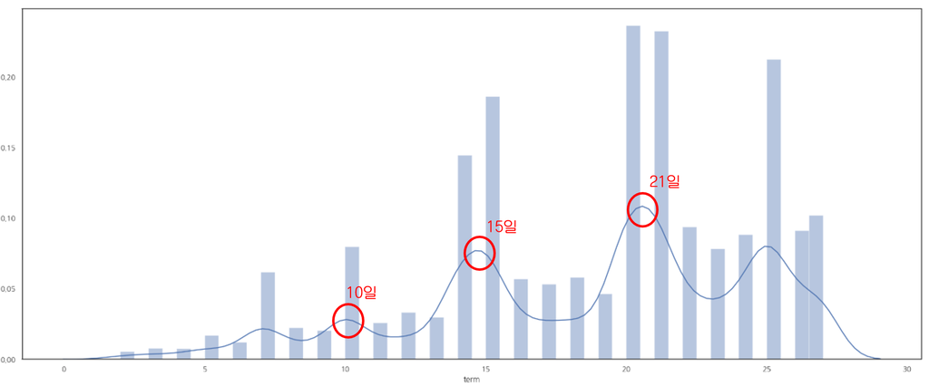

> term_bin1

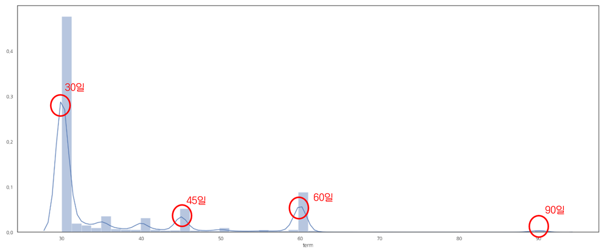

> term_bin2

> usd_goal_real

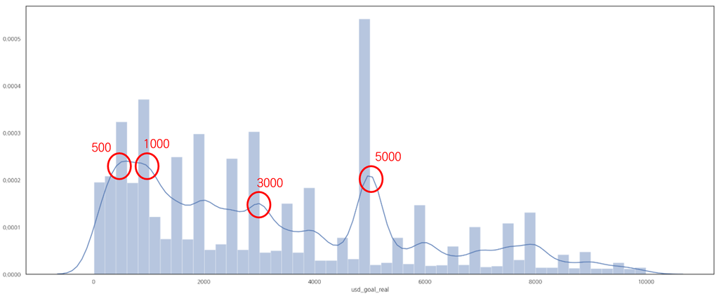

> goal_bin1

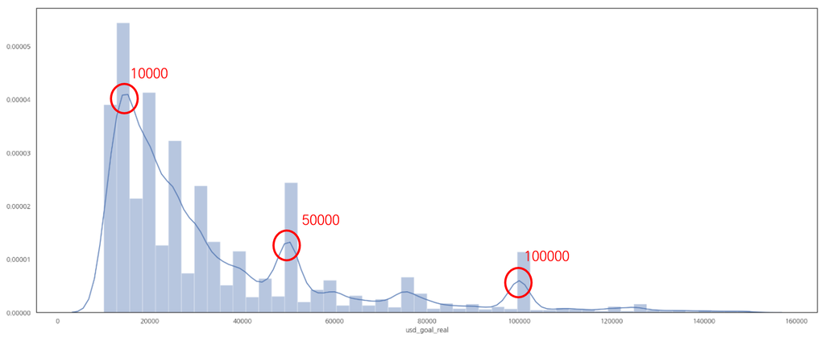

> goal_bin2

### EDA

#### >> state_new

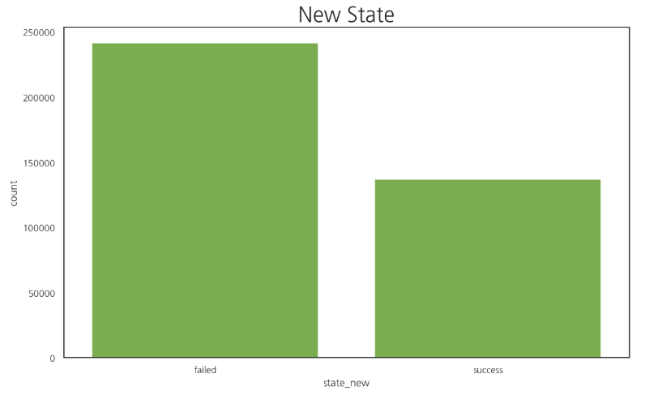

new_state

#### >> term

펀딩 기간을 binning 하지 않고 그래프를 그리면 나오는 그림은 아래와 같다.

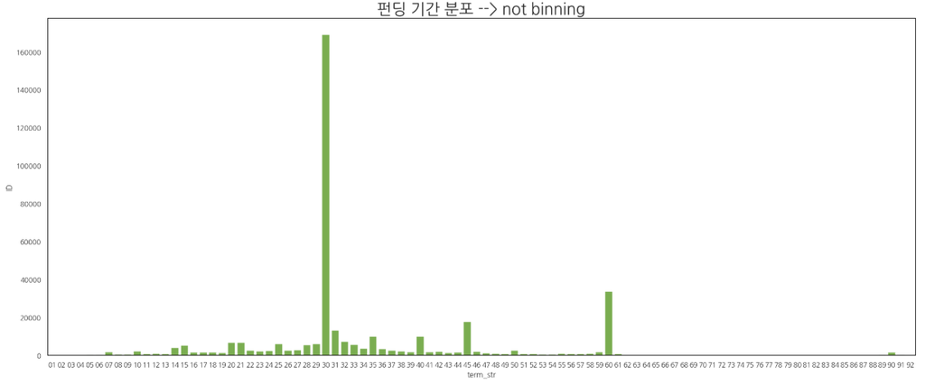

term_not_binning

펀딩 기간이 30일인 경우만 두드러지게 많아 다른 기간의 값은 보기가 어렵다. 이를 binning한 컬럼을 통해 같은 그래프로 그려보면 결과는 아래와 같다.

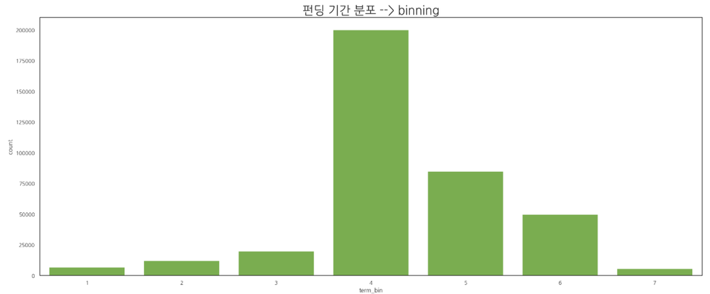

term_binning

여전히 30일이 포함된 4구간의 데이터가 가장 많지만, 이전보다는 전체적인 분포를 파악하기 쉬워졌다.

하지만 펀딩 기간의 분포가 높다고 해서 펀딩의 성공률도 높은 것은 아니었다.

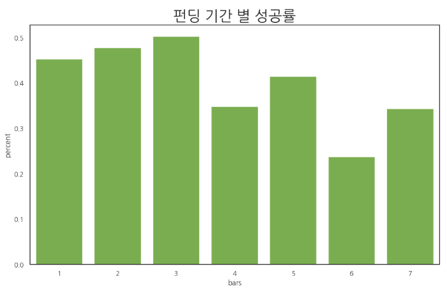

term_percent

펀딩 기간별 성공률은 대체로 0.4로 유사하기는 하지만, 1기간에서 3기간 사이일 때 가장 높다. 오히려 펀딩 기간 30일이 포함된 4구간에서는 펀딩의 성공률이 0.4를 넘지 못했다. 데이터의 양이 가장 많은만큼 당연히 성공률이 떨어진다고 생각할 수 있지만, 가장 많이 선택하는 기간으로 따라가는 것이 능사가 아님을 알 수 있다.

#### >> usd_goal_real

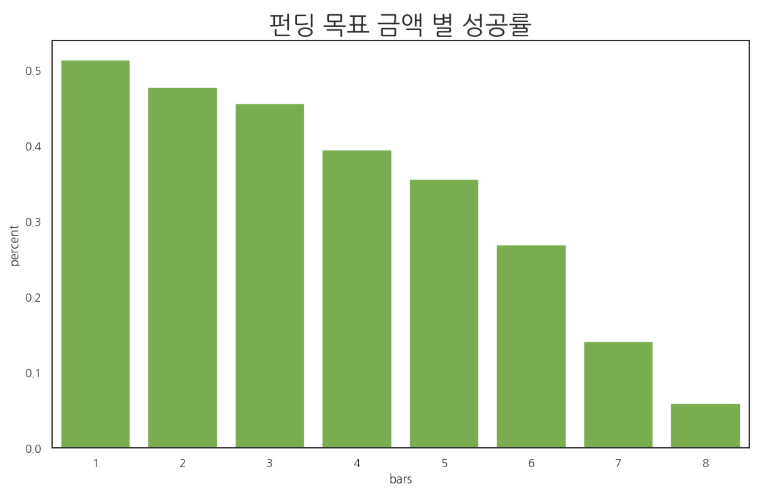

goal_percent

위의 그래프는 펀딩 목표 금액별로 성공률을 확인할 수 있게 해준다. 펀딩 목표 금액이 높을 수록 성공률이 지속적으로 감소하고 있다.

#### >> main_category

데이터에 포함된 15개의 main_category의 분포는 아래와 같다.

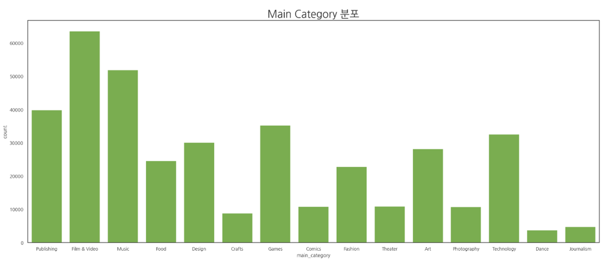

category

Film&Video가 가장 많고 Music, Publishing, Games, Technology가 그 뒤를 잇고 있다.

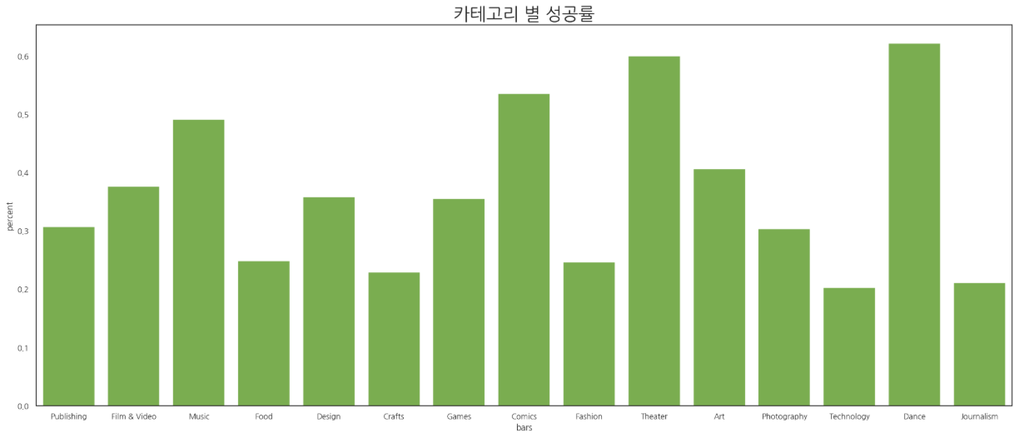

category_percent

하지만 카테고리 별 성공률은 매우 다른 양상을 보인다. Dance 카테고리의 성공률이 가장 높고, 그 다음이 Theater, Comics, Music, Art로 이루어져 있다.

### Modeling; 정확도를 향상 시키고 서비스 목표에 잘 부합하도록 모델을 개량하는 과정

#### >> 여러가지 모델과 전처리 기법을 시도하며 데이터의 특성 파악

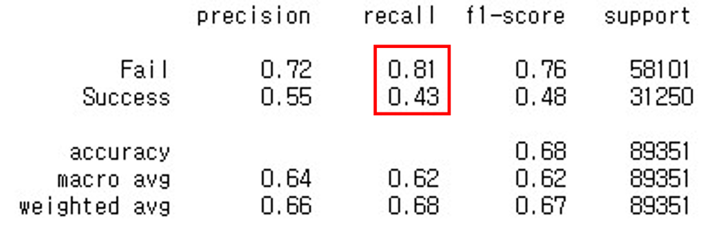

     xgboost

   - Random Forest without Grid Search

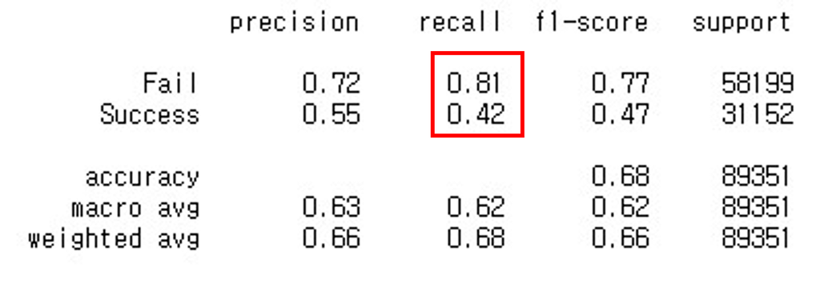

     randomforest

   - Recall Score로 정확도 확인

#### >> Problems and Solutions

- 카테고리에 따라 성공률이 많이 갈렸다. XGboost 모델에서 모델에 대한 기여도가 상위 20%를 차지하는 (쉽게 말하면 회귀계수의 절대값이 큰) 변수들은 대부분 카테고리였다.

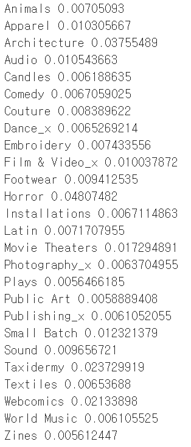

image

- 서비스 사용자가 입력하는 입력값은 카테고리를 하나씩만 가지기 때문에 (정확히는 카테고리와 하위 카테고리 각각 하나씩) 변별력이 큰 카테고리가 아닌 입력값의 경우 변별력이 떨어질 가능성이 있다. 따라서 임의로 카테고리의 영향력을 제한해서 모델을 만들어 볼 필요가 있다. 이를 위해서 카테고리만 따로 모델을 만들어 Voting을 통해 다른 컬럼들로 만들어진 모델들과 Ensemble 하는 것을 시도해 볼 수 있다. 이렇게 된다면 너무 많은 컬럼 수에 묻혀 과도하게 낮은 기여도를 가지게 된 변수들에게 적절한 기여도를 제공해 줄 수도 있다.

#### >> Plans

- 모델 개발(다양한 모델을 시도하고, 데이터에 맞는 고유의 모델 개발하며, Kaggle 우승작 등을 참고할 예정)과 튜닝
- 아예 다른 방법으로 접근해서 단변량 분석을 통해 컬럼 수를 초기 단계부터 활용하는 변수 개수를 확실히 줄이는 방법을 시도해 볼 수도 있다.
- PCA나 상관관계 분석을 통한 차원축소는 하지 않을 계획이다. 정확한 건 확인해야봐야 알겠지만, 이 데이터에 있어 각 변수가 의미하는 바를 명확히 알고 있으며 상관관계는 거의 없을 것으로 예상한다.

### Web 구현

#### >> 현재 웹사이트 구현 상태

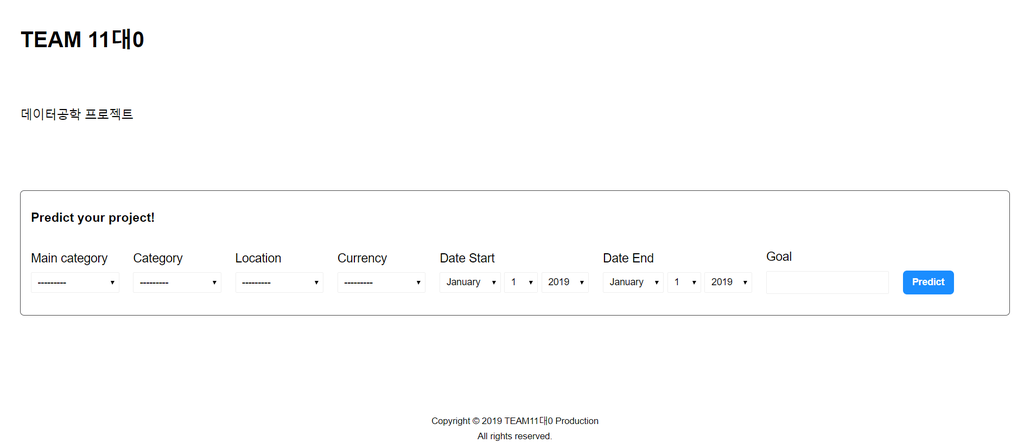

web

#### >> 웹에 추가 구현할 그래프

1. 특정 카테고리의 특정 기간의 금액별 성공률

```python
# parameter 2개 : main_category와 term_bin
# cate_success_by_term('Film & Video', 3)
```

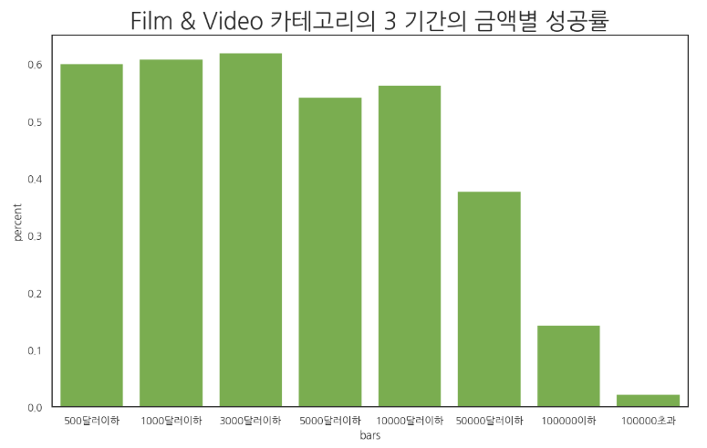

func1

2. 특정 카테고리의 특정 기간의 목표 금액 분포 및 성공 / 실패 비율

```python
# parameter 2개 : main_category와 term_bin
# cate_goal_dist('Film & Video', 1)
```

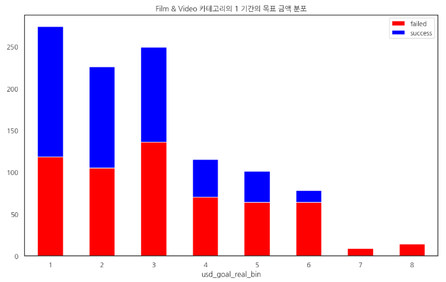

func2

3. 특정 카테고리의 특정 기간의 1인당 투자 금액 분포

```python
# parameter 2개 : main_category와 term_bin
# pledge_per_person('Film & Video', 2)
```

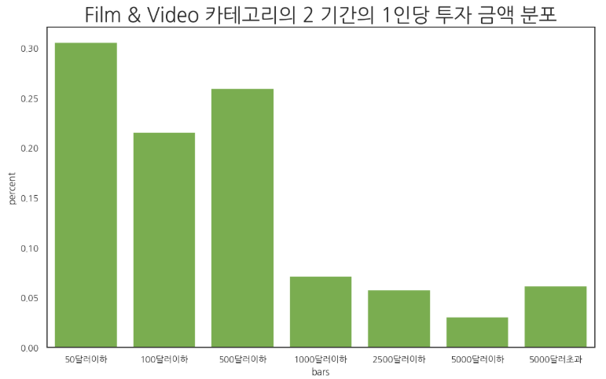

func3

### 향후 프로젝트 진행 방향

#### >> 역할 분담

| 팀원 | 중간고사 이전 | 중간고사 이후 |
| --- | --- | --- |
| 박지원 | Preprocessing | Modeling과 Front-end |
| 윤정하 | 자료 조사 | Modeling |
| 정희영 | Modeling | Front-end와 Server |
| 주용우 | 웹사이트 개발을 위한 서버 작업 | Modeling과 Back-end |

#### >> 구체적인 추가 진행 목록

1. **NLP** : 펀딩의 성공과 실패 여부는 그 아이디어의 내용이 펀딩을 할 가치가 있는지에 가장 큰 영향을 받을 것이다. 아직 데이터에 프로젝트의 정확한 내용은 나와있지 않지만, kickstarter 홈페이지에 프로젝트 이름을 검색하여 내용을 크롤링하는 방식을 통해 그 아이디어가 구체적으로 어떤 것을 실행하려 하는지를 분석하고자 한다. 이렇게 NLP로 분석한 결과를 토대로 성공률 예측에 추가적으로 사용할 것이다.
2. **모델링 심화**
   - 더 많은 ML 기법을 사용하고 더 정확하게 scaling하는 방식을 통해 정확도를 높이고자 한다. 추가적으로 사용할 ML 기법으로는 Catboost가 있다.
   - plat_pop 변수 방식 변경
   - EDA에서는 binning을 한 컬럼을 사용하였지만, 모델링에서는 binning하지 않은 raw 컬럼 상태로 활용해보려한다.
3. **웹 개발** : 분석에 사용한 최종 모델을 백엔드에 저장하여 서비스 이용 고객들이 개인의 아이디어에 맞는 카테고리, 펀딩 기간 등을 입력하면 그 성공률이 바로 웹에 띄워지도록 하는 작업을 할 것이다. 또한 추가적인 정보를 제공하는 그래프를 띄우는 함수까지 백엔드에 저장해 완전한 웹을 구현하고자 한다. 그리고 웹 프론트엔드 템플릿을 가공하여 더 보기 좋은 UI / UX를 구현할 것이다.

### Reference

Kickstarter 설명

[크라우드 펀딩 전망 1](http://www.eroun.net/news/articleView.html?idxno=4160)

- Python
- R
- Django

### 사용중인 AWS 기술들

- EC2
- RDS